# 时间序列预测方法总结

## 一、数据准备

```python
import matplotlib.pyplot as plt
import numpy as np
import pandas as pd
import tensorflow as tf
from math import sqrt
from sklearn.metrics import mean_squared_error, mean_absolute_percentage_error
from statsmodels.graphics.tsaplots import plot_acf
from statsmodels.tsa.api import ExponentialSmoothing, Holt, SimpleExpSmoothing
from statsmodels.tsa.arima.model import ARIMA
from statsmodels.tsa.seasonal import seasonal_decompose
from statsmodels.tsa.statespace.sarimax import SARIMAX

# 设置画布大小
plt.rcParams["figure.figsize"] = (12, 6)
```

```python
data = pd.read_csv('AirPassengers.csv', index_col='Month')
data.index = pd.DatetimeIndex(data.index)
data
```

| Month | #Passengers |
| --- | --- |
| 1949-01-01 | 112 |
| 1949-02-01 | 118 |
| 1949-03-01 | 132 |
| 1949-04-01 | 129 |
| 1949-05-01 | 121 |
| ... | ... |
| 1960-08-01 | 606 |
| 1960-09-01 | 508 |
| 1960-10-01 | 461 |
| 1960-11-01 | 390 |
| 1960-12-01 | 432 |

144 rows × 1 columns

```python
# 划分训练集
X = data[:'19580101']
y = data['19580101':]
X.shape, y.shape
```

```
((109, 1), (36, 1))
```

```python
def eval_errors(y, y_pred):
    # 计算误差
    print('RMSE:', sqrt(mean_squared_error(y, y_pred)))
    print('MAPE:', mean_absolute_percentage_error(y, y_pred))
```

```python
def data_vis(X, y, y_pred=None, title=''):
    # 数据可视化
    # plt.figure(figsize=(10, 6))
    plt.plot(X.index, X['#Passengers'], label='X')
    plt.plot(y.index, y['#Passengers'], label='y')
    if y_pred is not None:
        plt.plot(y_pred.index, y_pred['#Passengers'], label=title)
    plt.legend(loc='best')
    plt.xlabel('Month')
    plt.ylabel('#Passengers')
    plt.title(title)
    plt.show()
```

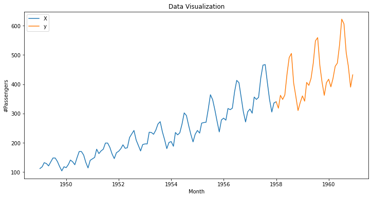

```python
data_vis(X, y, title='Data Visualization')
```

## 二、简单预测方法

### 2.1 均值法

$$ \hat{y}_{T+h|T} = \bar{y} = (y_{1}+\dots+y_{T})/T $$

其中，$\hat{y}_{T+h|T}$ 代表基于 $y_1,\dots,y_T$ 对 $y_{T+h}$ 的估计值。

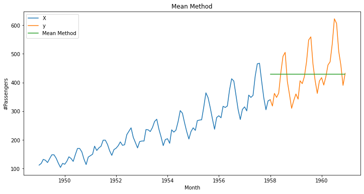

```
RMSE: 78.21959828301061
MAPE: 0.14900947128638758
```

```python
y_pred = y.copy()
y_pred['#Passengers'] = y['#Passengers'].mean()
data_vis(X, y, y_pred, title='Mean Method')
eval_errors(y, y_pred)
```

### 2.2 Naïve 方法

在 naïve 预测方法中，我们简单地将所有预测值设为最后一次的观测值，即：

$$ \hat{y}_{T+h|T} = y_{T} $$

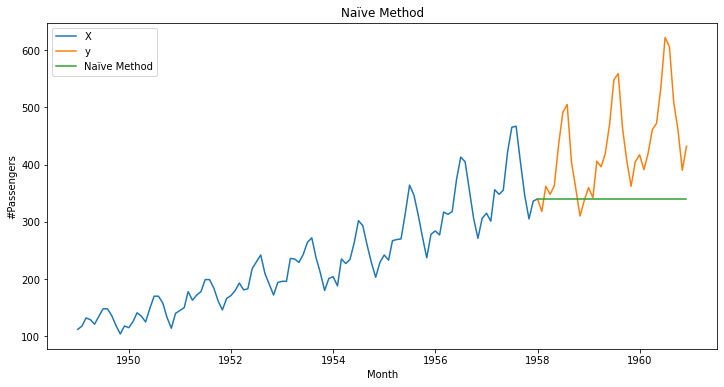

```
RMSE: 118.11246994096582
MAPE: 0.19114713423532398
```

```python
y_pred = y.copy()
y_pred['#Passengers'] = X['#Passengers'][-1]
data_vis(X, y, y_pred, title='Naïve Method')
eval_errors(y, y_pred)
```

### 2.3 季节性 Naïve 方法

季节性 Naïve 方法与 Naïve 方法类似，它适用于季节性变化剧烈的数据。我们将每个预测值设为同一季节的前一期观测值（例如：去年的同一个月）。那么，$T+h$ 时刻的预测值可以记作：

$$ \hat{y}_{T+h|T} = y_{T+h-km} $$

式中 $m$ 为周期长度，$k$ 是 $(h-1)/m$ 的整数部分（也就是在 $T+h$ 时刻前预测期所包含的整年数）。

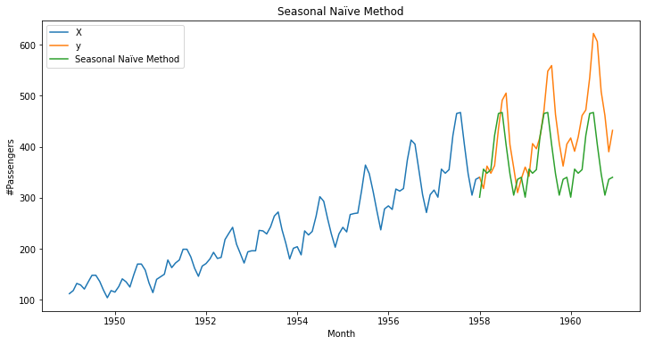

```
RMSE: 84.68306927728956
MAPE: 0.14944866731206308
```

```python
h = 12
sliding_window = np.array(X['#Passengers'][-h:])
y_pred = y.copy()
for i in range(y_pred.shape[0]):
    pred = sliding_window[0]
    y_pred.iloc[i] = pred
    sliding_window = np.append(sliding_window[1:], pred)

data_vis(X, y, y_pred, title='Seasonal Naïve Method')
eval_errors(y, y_pred)
```

### 2.4 趋势法

趋势法（漂移法）允许预测值随着时间的推移增大或减小，并且我们假定单位时间改变量（称作 “漂移”）等于历史数据的平均改变量，因此 $T+h$ 时刻的预测值可以表示为：

$$ \hat{y}_{T+h|T} = y_{T} + \frac{h}{T-1}\sum_{t=2}^T (y_{t}-y_{t-1}) = y_{T} + h \left( \frac{y_{T} -y_{1}}{T-1}\right) $$

这相当于把第一个观测点和最后一个观测点连成一条直线并延伸到未来预测点。

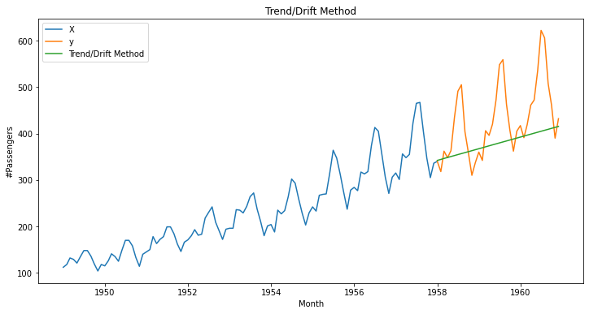

```
RMSE: 85.35442670107415
MAPE: 0.12602129627916822
```

```python
y_pred = y.copy()
step = (X['#Passengers'][-1] - X['#Passengers'][0]) / X.shape[0]
last_value = X['#Passengers'][-1]
for i in range(y_pred.shape[0]):
    y_pred.iloc[i] = last_value + step
    last_value += step

data_vis(X, y, y_pred, title='Trend/Drift Method')
eval_errors(y, y_pred)
```

## 三、时间序列分解

时间序列数据通常有很多种潜在模式，因此一种有效的处理时间序列的方式是将其分解为多个成分，其中每个成分都对应某一种基础模式。

时间序列数据有三种基础的时间序列模式：**趋势性**，**季节性**和**周期性**。

当我们想要把时间序列分解为多个成分时，我们通常将趋势和周期组合为“趋势-周期”项（有时也简单称其为趋势项）。

因此，我们认为时间序列包括三个成分：**趋势-周期项**，**季节项**和**残差项**（残差项包含时间序列中其它所有信息）。

1. 假设一条时间序列是由多种成分相加得来，那么它可以写为如下形式：

$$ y_{t} = S_{t} + T_{t} + R_t $$

1. 时间序列也可以写成相乘的形式：

$$ y_{t} = S_{t} \times T_{t} \times R_t $$

如果季节性波动的幅度或者趋势周期项的波动不随时间序列水平的变化而变化，那么加法模型是最为合适的。当季节项或趋势周期项的变化与时间序列的水平成比例时，则乘法模型更为合适。

使用乘法分解的一种替代方法是：首先对数据进行变换，直到时间序列随时间的波动趋于稳定，然后再使用加法分解。显然，采用对数变换的加法模型，等价于乘法模型：

$$ y_{t} = S_{t} \times T_{t} \times R_t \quad\text{等价于}\quad \log y_{t} = \log S_{t} + \log T_{t} + \log R_t $$

在上式中，$y_t$ 表示时间序列数据，$S_t$ 表示季节项，$T_t$ 表示趋势-周期项，$R_t$ 表示残差项。

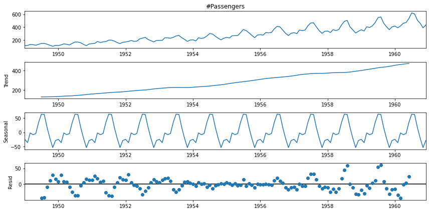

```python
# 时间序列分解
# 原始数据、趋势、季节性、残差
seasonal_decompose(data['#Passengers']).plot()
plt.show()
```

## 四、基于统计学的方法

这类方法和线性回归有一定类似，会用到线性回归来解释不同时间下数据点之间的关系。

和一般线性回归的区别是一般线性回归分析假定不同数据点之间是独立的，而时间序列数据分析的一个重要前提是各个数据点之间存在关联。

### 4.1 指数平滑（Exponential Smoothing）

使用指数平滑方法生成的预测是过去观测值的加权平均值，并且随着过去观测值离预测值距离的增大，权重呈指数型衰减。换句话说，观察值越近，相应的权重越高。

指数平滑是用于**单变量数据**的时间序列预测方法，可以扩展到支持具有**系统趋势**或**季节性成分**的数据。

这类模型一般统称为 ETS 模型，即对误差（Error）、趋势（Trend）和季节性（Seasonality）统一建模。

#### 4.1.1 一次指数平滑（SES，Single Exponential Smoothing）

也称简单指数平滑（SES，Simple Exponential Smoothing），这种方法适用于预测没有明显趋势或季节因素的数据。

一次指数平滑的方程如下：

$$ \begin{aligned} \hat{y}_{T+1|T} &= \alpha y_T + (1-\alpha) \hat{y}_{T|T-1} \\ &= \alpha y_T + \alpha(1-\alpha) y_{T-1} + \alpha(1-\alpha)^2 y_{T-2}+ \alpha(1-\alpha)^3 y_{T-3}+\cdots \end{aligned} $$

其中 $0 \le \alpha \le 1$ 是平滑参数。权重下降的速度由参数 $\alpha$ 控制，值越大衰减越快。

一次指数平滑可以看作是在平均法和朴素法这两个极端方法之间的折衷方法：将更大的权重赋到最近的观测值。

**分量形式**：

对于简单的指数平滑，级别 $\ell_t$ 是唯一的分量。

$$ \begin{align*} \text{Forecast equation} && \hat{y}_{t+h|t} & = \ell_{t}\\ \text{Smoothing equation} && \ell_{t} & = \alpha y_{t} + (1 - \alpha)\ell_{t-1} \end{align*} $$

**平面预测**：

简单的指数平滑具有一个“平坦”的预测函数：

$$ \hat{y}_{T+h|T} = \hat{y}_{T+1|T} = \ell_T, \qquad h=1,2,3,\dots $$

也就是说，所有预测值都相同，等于最后一个级别分量。

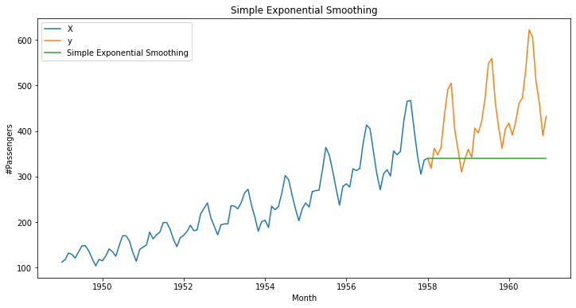

```
RMSE: 117.83406352218151
MAPE: 0.1905054536633423
```

```python
# 一次指数平滑
y_pred = y.copy()
ses = SimpleExpSmoothing(X['#Passengers'].values).fit(smoothing_level=0.5, optimized=False)
y_pred['#Passengers'] = ses.forecast(y.shape[0])

data_vis(X, y, y_pred, 'Simple Exponential Smoothing')
eval_errors(y, y_pred)
```

#### 4.1.2 二次指数平滑（Double Exponential Smoothing）

二次指数平滑也称霍尔特的线性趋势法（Holt's Linear Trend Method），是一次指数平滑的扩展，该方法包含一个预测方程和两个平滑方程（一个用于水平，一个用于趋势）：

$$ \begin{align*} \text{Forecast equation}&& \hat{y}_{t+h|t} &= \ell_{t} + hb_{t} \\ \text{Level equation} && \ell_{t} &= \alpha y_{t} + (1 - \alpha)(\ell_{t-1} + b_{t-1})\\ \text{Trend equation} && b_{t} &= \beta^*(\ell_{t} - \ell_{t-1}) + (1 -\beta^*)b_{t-1} \end{align*} $$

其中，$\ell_t$ 表示在 $t$ 时刻该时间序列的水平的估计值，$b_t$ 表示在 $t$ 时刻的趋势（斜率）的估计，$\alpha$ 是水平 $0\le\alpha\le1$ 的平滑参数，$\beta^*$ 是趋势 $0\le\beta^*\le1$ 的平滑参数。$\beta^*$ 取值非常小意味着斜率几乎不随时间变化。

趋势，分为**加性趋势（Addtive Trend）**和**乘性趋势（Multiplicative Trend）**。

- **加性趋势（Addtive Trend）**：用序列中相邻变量的差值来表示趋势，如：

$$ x_{i+1}=x_i+(x_{i+1}-x_i) $$

- **乘性趋势（Multiplicative Trend）**：用序列中相邻变量的比值来表示趋势，如：

$$ x_{i+1}=x_i\frac{x_{i+1}}{x_i} $$

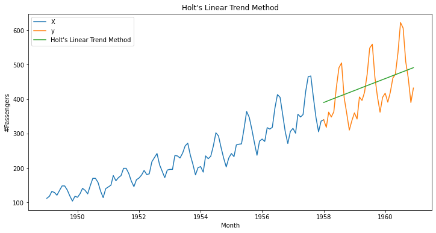

```
RMSE: 68.55749482961873
MAPE: 0.13923635640627297
```

```python
# 二次指数平滑（加性趋势）
y_pred = y.copy()
holt = Holt(X['#Passengers'].values).fit(smoothing_level=0.1, smoothing_trend=0.1)
y_pred['#Passengers'] = holt.forecast(y.shape[0])

data_vis(X, y, y_pred, "Holt's Linear Trend Method")
eval_errors(y, y_pred)
```

#### 4.1.3 三次指数平滑（Triple Exponential Smoothing）

三次指数平滑也称 Holt-Winters 季节性方法（Holt-Winters's Seasonal Method），是二次指数平滑的扩展，增加了对单变量时间序列的季节性支持。

Holt-Winters 季节性方法包括预测方程和三个平滑方程——一个用于水平 $\ell_t$，一个用于趋势 $b_t$，另一个用于季节性分量 $s_t$，相应的平滑参数分别为 $\alpha$，$\beta^*$ 和 $\gamma$。我们用 $m$ 来表示季节频率，即一年中包含的季节数。例如，季度数据的 $m=4$，月度数据的 $m=12$。

这种方法有两种不同的季节性组成部分。当季节变化在该时间序列中大致保持不变时，通常选择加法模型；而当季节变化与时间序列的水平成比例变化时，通常选择乘法模型。在加法模型中，季节性分量在观测序列的尺度上以绝对值表示，在水平方程中，时间序列通过减去季节分量进行季节性调整，并且每年的季节性分量加起来大约为零。在乘法模型中，季节性分量用相对数（百分比）表示，时间序列通过除以季节性分量来进行季节性调整，并且每年的季节性分量加起来约为 $m$。

**Holt-Winters 加法模型**：

$$ \begin{align*} \hat{y}_{t+h|t} &= \ell_{t} + hb_{t} + s_{t-m+h_{m}^{+}} \\ \ell_{t} &= \alpha(y_{t} - s_{t-m}) + (1 - \alpha)(\ell_{t-1} + b_{t-1})\\ b_{t} &= \beta^*(\ell_{t} - \ell_{t-1}) + (1 - \beta^*)b_{t-1}\\ s_{t} &= \gamma^* (y_{t}-\ell_{t})+ (1-\gamma^*)s_{t-m} \\ &= \gamma (y_{t}-\ell_{t-1}-b_{t-1}) + (1-\gamma)s_{t-m} \end{align*} $$

**Holt-Winters 乘法模型**：

$$ \begin{align*} \hat{y}_{t+h|t} &= (\ell_{t} + hb_{t})s_{t-m+h_{m}^{+}} \\ \ell_{t} &= \alpha \frac{y_{t}}{s_{t-m}} + (1 - \alpha)(\ell_{t-1} + b_{t-1})\\ b_{t} &= \beta^*(\ell_{t}-\ell_{t-1}) + (1 - \beta^*)b_{t-1} \\ s_{t} &= \gamma \frac{y_{t}}{(\ell_{t-1} + b_{t-1})} + (1 - \gamma)s_{t-m} \end{align*} $$

其中，$\gamma=\gamma^*(1-\alpha)$，通常的参数限制是 $0\le\gamma^*\le1$，可以将其转换为 $0\le\gamma\le 1-\alpha$。

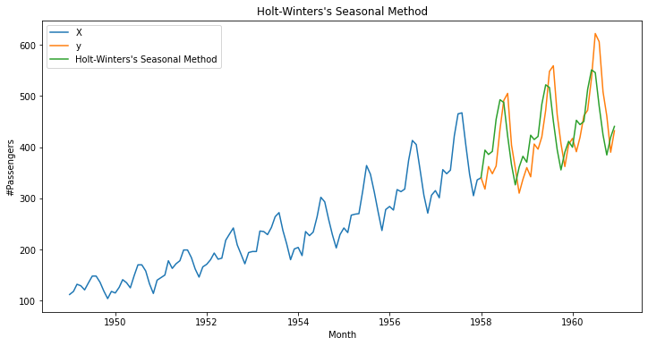

```
RMSE: 55.52499761659812
MAPE: 0.10709816475376649
```

```python
# 三次指数平滑（加法模型）
y_pred = y.copy()
es = ExponentialSmoothing(X['#Passengers'].values, seasonal_periods=12, trend='add', seasonal='add').fit()
y_pred['#Passengers'] = es.forecast(y.shape[0])

data_vis(X, y, y_pred, "Holt-Winters's Seasonal Method")
eval_errors(y, y_pred)
```

### 4.2 差分自回归移动平均（ARIMA）

指数平滑模型和 ARIMA（AutoRegressive Integrated Moving Average） 模型是应用最为广泛的两种时间序列预测方法。

与指数平滑模型针对于数据中的趋势（trend）和季节性（seasonality）不同，ARIMA 模型旨在描绘数据的自回归性（autocorrelations）。

**平稳性**：

平稳的时间序列的性质不随观测时间的变化而变化。

因此具有趋势或季节性的时间序列不是平稳时间序列——趋势和季节性使得时间序列在不同时段呈现不同性质。

对数变换的变换方法可用于平稳化（stabilize）时间序列的方差。

**差分**：

我们注意到每天的数值并不平稳，但每天的变化量则是平稳的。

这向我们展示了一种让非平稳时间序列变平稳的方法——计算相邻观测值之间的差值，这种方法被称为差分。

差分则可以通过去除时间序列中的一些变化特征来平稳化它的均值，并因此消除（或减小）时间序列的趋势和季节性。

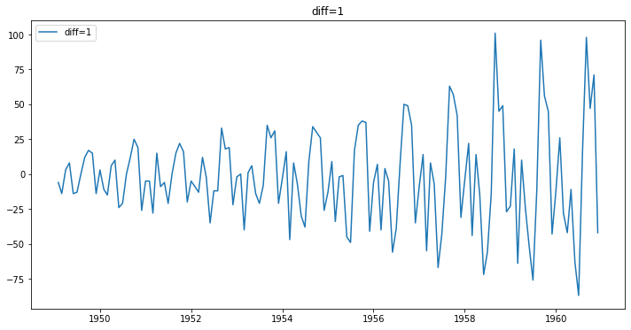

```python
data_diff = data.shift(1) - data
plt.plot(data_diff, label='diff=1')
plt.legend()
plt.title('diff=1')
plt.show()
```

**自相关（ACF，Autocorrelation Function）图**

和时间曲线图一样，自相关图（ACF图）也能帮助我们识别非平稳时间序列。

对于一个平稳时间序列，自相关系数（ACF）会快速的下降到接近 0 的水平，然而非平稳时间序列的自相关系数会下降的比较缓慢。

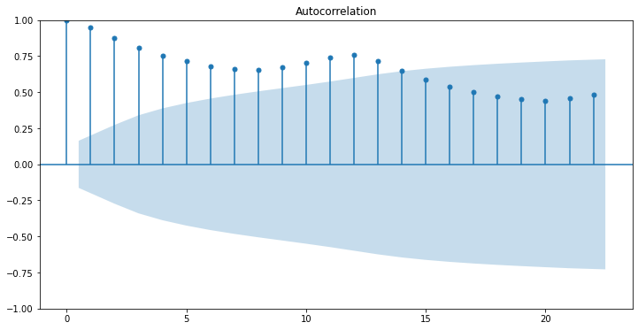

```python
plot_acf(data)
plt.show()
```

#### 4.2.1 自回归（AR，AutoRegressive）

在多元线性回归模型中，我们通过对多个预测变量（predictor）的线性组合预测了目标变量（variable of interest）。

在自回归模型中，我们则是基于目标变量历史数据的组合对目标变量进行预测。自回归一词中的自字即表明其是对变量自身进行的回归。

因此，一个 $p$ 阶的自回归模型可以表示如下：

$$ y_{t} = c + \phi_{1}y_{t-1} + \phi_{2}y_{t-2} + \dots + \phi_{p}y_{t-p} + \varepsilon_{t} $$

其中，$\varepsilon_{t}$ 表示白噪声，$\phi$ 表示自回归系数。这就相当于将预测变量替换为目标变量的历史值的多元回归。

我们将这个模型称为 $AR(p)$ 模型—— $p$ 阶自回归模型。

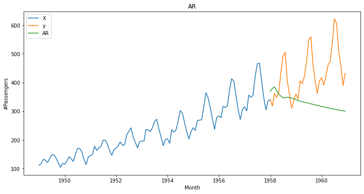

```
RMSE: 134.17012363068335
MAPE: 0.22666853282043917
```

```python
# AR
ar = ARIMA(X['#Passengers'], order=(7, 0, 0)).fit()
y_pred = ar.predict(start=y.index[0], end=y.index[-1], dynamic=True)
y_pred = pd.DataFrame(y_pred)
y_pred.columns = ['#Passengers']

data_vis(X, y, y_pred, 'AR')
eval_errors(y, y_pred)
```

#### 4.2.2 移动平均（MA，Moving Average）

将一段时间序列中白噪声(误差)进行加权求和。

$q$ 阶移动平均方程如下：

$$ MA(q): \ x_{t}=\mu+\mu_{t}+\theta_{1}\mu_{t-1}+\theta_{2}\mu_{t-2}+\cdots+\theta_{q}\mu_{t-q} $$

其中，$μ_t$ 表示白噪声，$\theta$ 表示移动平均系数。

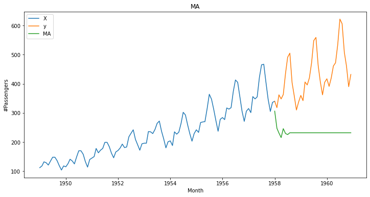

```
RMSE: 211.12716936846746
MAPE: 0.43523707422480823
```

```python
# MA
ma = ARIMA(X['#Passengers'], order=(0, 0, 7)).fit()
y_pred = ma.predict(start=y.index[0], end=y.index[-1], dynamic=True)
y_pred = pd.DataFrame(y_pred)
y_pred.columns = ['#Passengers']

data_vis(X, y, y_pred, 'MA')
eval_errors(y, y_pred)
```

#### 4.2.3 自回归移动平均（ARMA，AutoRegressive Moving Average）

$(p,q)$ 阶自回归移动平均方程如下：

$$ ARMA(p,q)=AR(p)+MA(q) \\ ARMA(p,q) : \ x_{t}=\phi_{1}x_{t-1}+\phi_{2}x_{t-2}+\cdots+\phi_{p}x_{t-p}+\mu_{t}+\theta_{1}\mu_{t-1}+\theta_{2}\mu_{t-2}+\cdots+\theta_{q}\mu_{t-q} $$

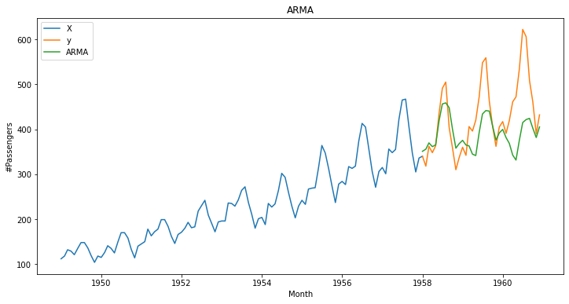

```
RMSE: 75.97181315599079
MAPE: 0.1160538485258059
```

```python
# ARMA
arma = ARIMA(X['#Passengers'], order=(7, 0, 7)).fit()
y_pred = arma.predict(start=y.index[0], end=y.index[-1], dynamic=True)
y_pred = pd.DataFrame(y_pred)
y_pred.columns = ['#Passengers']

data_vis(X, y, y_pred, 'ARMA')
eval_errors(y, y_pred)
```

#### 4.2.4 差分自回归移动平均（ARIMA，AutoRegressive Integrated Moving Average）

$(p,d,q)$ 阶差分自回归移动平均方程如下：

$$ ARIMA(p, d, q) : \ x_{t}=\phi_{1}w_{t-1}+\phi_{2}w_{t-2}+\cdots+\phi_{p}w_{t-p}+\mu_{t}+\theta_{1}\mu_{t-1}+\theta_{2}\mu_{t-2}+\cdots+\theta_{q}\mu_{t-q} $$

其中，$w_t$ 表示 $x_t$ 经过 $d$ 阶差分以后的结果。

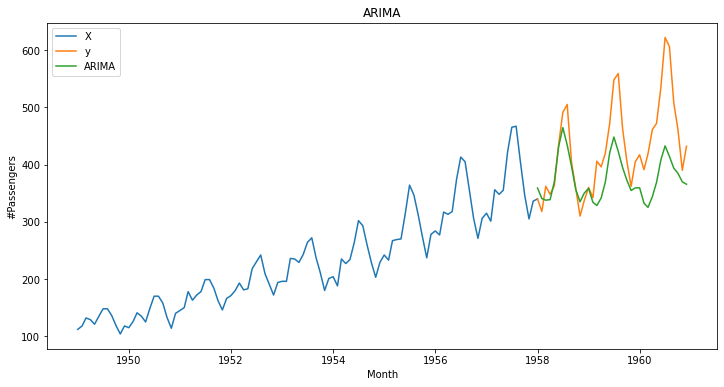

```
RMSE: 76.5707202061421
MAPE: 0.12212073296842478
```

```python
# ARIMA
arima = ARIMA(X['#Passengers'], order=(7, 1, 7)).fit()
y_pred = arima.predict(start=y.index[0], end=y.index[-1], dynamic=True)
y_pred = pd.DataFrame(y_pred)
y_pred.columns = ['#Passengers']

data_vis(X, y, y_pred, 'ARIMA')
eval_errors(y, y_pred)
```